# Job_Analysis_Project-Phase1

## Data Exploration Phase-1

```python
import pandas as pd
import warnings
warnings.filterwarnings("ignore")
```

## Load Dataset

```python
df=pd.read_csv("jobs.csv")
```

## Observation

- Dataset has been loaded successfully using pd.read_csv()

### Understanding the Structure of the Dataset

```python
df.shape
```

```
(79147, 12)
```

## Observation:

- The dataset contains 79147 rows and 12 columns representing various job-related features.

## Previewing the few rows from dataset

```python
df
```

|  | job_id | job_role | company | experience | salary | location | rating | reviews | resposibilities | posted_on | job_link | company_link |
| --- | --- | --- | --- | --- | --- | --- | --- | --- | --- | --- | --- | --- |
| 0 | 7.012301e+10 | Branch Banking - Calling For Women Candidates | Hdfc Bank | 1-6 Yrs | Not disclosed | Kolkata, Hyderabad/Secunderabad, Pune, Ahmedab... | 4.0 | 39110 Reviews | Customer Service,Sales,Relationship Management | 1 Day Ago | https://www.naukri.com/job-listings-branch-ban... | https://www.naukri.com/hdfc-bank-jobs-careers-213 |
| 1 | 6.012391e+10 | Product Owner Senior Manager | Accenture | 11-15 Yrs | Not disclosed | Kolkata, Mumbai, Hyderabad/Secunderabad, Pune,... | 4.1 | 32129 Reviews | Product management,Market analysis,Change mana... | 1 Day Ago | https://www.naukri.com/job-listings-product-ow... | https://www.naukri.com/accenture-jobs-careers-... |
| 2 | 6.012391e+10 | Employee Relations and Policies Associate Manager | Accenture | 3-7 Yrs | Not disclosed | Kolkata, Mumbai, Hyderabad/Secunderabad, Pune,... | 4.1 | 32129 Reviews | Business process,Change management,Team manage... | 1 Day Ago | https://www.naukri.com/job-listings-employee-r... | https://www.naukri.com/accenture-jobs-careers-... |
| 3 | 6.012391e+10 | Employee Relations and Policies Specialist | Accenture | 3-7 Yrs | Not disclosed | Kolkata, Mumbai, Hyderabad/Secunderabad, Pune,... | 4.1 | 32129 Reviews | Business process,Change management,Team manage... | 1 Day Ago | https://www.naukri.com/job-listings-employee-r... | https://www.naukri.com/accenture-jobs-careers-... |
| 4 | 6.012301e+10 | SAP BO Consultant | Mindtree | 5-7 Yrs | Not disclosed | Hybrid - Kolkata, Hyderabad/Secunderabad, Pune... | 4.1 | 3759 Reviews | SAP BO,PL / SQL,Oracle SQL,SAP Business Object... | 1 Day Ago | https://www.naukri.com/job-listings-sap-bo-con... | https://www.naukri.com/mindtree-jobs-careers-3... |
| ... | ... | ... | ... | ... | ... | ... | ... | ... | ... | ... | ... | ... |
| 79142 | 6.012301e+10 | .Net Fullstack Developer | Citiustech | 3-8 Yrs | 7,00,000 - 17,00,000 PA. | Hybrid - Pune, Bangalore/Bengaluru, Mumbai (Al... | 4.0 | 742 Reviews | c#,.net core,javascript,Microservices,Angular,... | 2 Days Ago | https://www.naukri.com/job-listings-net-fullst... | https://www.naukri.com/citiustech-jobs-careers... |
| 79143 | 1.122201e+10 | Senior (BI) Business Intelligence Architect | Hexaware Technologies | 10-13 Yrs | Not disclosed | Hybrid - Pune, Chennai, Bangalore/Bengaluru, M... | 3.7 | 3172 Reviews | Informatica Mdm,etl,business intelligence,Agil... | 1 Day Ago | https://www.naukri.com/job-listings-senior-bi-... | https://www.naukri.com/hexaware-technologies-j... |
| 79144 | 1.512220e+11 | PowerBI Developer | EY | 5-10 Yrs | Not disclosed | Hybrid - Pune, Mumbai (All Areas) | 3.8 | 6267 Reviews | pagination,Power Bi,Dax | 2 Days Ago | https://www.naukri.com/job-listings-powerbi-de... | https://www.naukri.com/ey-jobs-careers-9156 |
| 79145 | 2.712220e+11 | Customer Service Associate | Tech Mahindra | 0-2 Yrs | 2,50,000 - 3,50,000 PA. | Temp. WFH - Noida, Kolkata, New Delhi, Hyderab... | 3.7 | 21440 Reviews | Bengali,International BPO,BPO,Customer Service... | 10 Days Ago | https://www.naukri.com/job-listings-customer-s... | https://www.naukri.com/tech-mahindra-jobs-care... |
| 79146 | 2.112220e+11 | Senior Java BED ( PAN India)- KG | Tech Mahindra | 8-12 Yrs | 25,00,000 - 27,50,000 PA. | Temp. WFH - Noida, Kolkata, Hyderabad/Secunder... | 3.7 | 21440 Reviews | Kafka,sql,spring boot,REST API,java,Lambda,Des... | 3 Days Ago | https://www.naukri.com/job-listings-senior-jav... | https://www.naukri.com/born-commerce-jobs-care... |

79147 rows × 12 columns

```python
df.head()
```

|  | job_id | job_role | company | experience | salary | location | rating | reviews | resposibilities | posted_on | job_link | company_link |
| --- | --- | --- | --- | --- | --- | --- | --- | --- | --- | --- | --- | --- |
| 0 | 7.012301e+10 | Branch Banking - Calling For Women Candidates | Hdfc Bank | 1-6 Yrs | Not disclosed | Kolkata, Hyderabad/Secunderabad, Pune, Ahmedab... | 4.0 | 39110 Reviews | Customer Service,Sales,Relationship Management | 1 Day Ago | https://www.naukri.com/job-listings-branch-ban... | https://www.naukri.com/hdfc-bank-jobs-careers-213 |
| 1 | 6.012391e+10 | Product Owner Senior Manager | Accenture | 11-15 Yrs | Not disclosed | Kolkata, Mumbai, Hyderabad/Secunderabad, Pune,... | 4.1 | 32129 Reviews | Product management,Market analysis,Change mana... | 1 Day Ago | https://www.naukri.com/job-listings-product-ow... | https://www.naukri.com/accenture-jobs-careers-... |
| 2 | 6.012391e+10 | Employee Relations and Policies Associate Manager | Accenture | 3-7 Yrs | Not disclosed | Kolkata, Mumbai, Hyderabad/Secunderabad, Pune,... | 4.1 | 32129 Reviews | Business process,Change management,Team manage... | 1 Day Ago | https://www.naukri.com/job-listings-employee-r... | https://www.naukri.com/accenture-jobs-careers-... |
| 3 | 6.012391e+10 | Employee Relations and Policies Specialist | Accenture | 3-7 Yrs | Not disclosed | Kolkata, Mumbai, Hyderabad/Secunderabad, Pune,... | 4.1 | 32129 Reviews | Business process,Change management,Team manage... | 1 Day Ago | https://www.naukri.com/job-listings-employee-r... | https://www.naukri.com/accenture-jobs-careers-... |
| 4 | 6.012301e+10 | SAP BO Consultant | Mindtree | 5-7 Yrs | Not disclosed | Hybrid - Kolkata, Hyderabad/Secunderabad, Pune... | 4.1 | 3759 Reviews | SAP BO,PL / SQL,Oracle SQL,SAP Business Object... | 1 Day Ago | https://www.naukri.com/job-listings-sap-bo-con... | https://www.naukri.com/mindtree-jobs-careers-3... |

## Observations

- get the top n number of rows from the dataset using df.head() deafult 5 rows

```python
df.tail()
```

|  | job_id | job_role | company | experience | salary | location | rating | reviews | resposibilities | posted_on | job_link | company_link |
| --- | --- | --- | --- | --- | --- | --- | --- | --- | --- | --- | --- | --- |
| 79142 | 6.012301e+10 | .Net Fullstack Developer | Citiustech | 3-8 Yrs | 7,00,000 - 17,00,000 PA. | Hybrid - Pune, Bangalore/Bengaluru, Mumbai (Al... | 4.0 | 742 Reviews | c#,.net core,javascript,Microservices,Angular,... | 2 Days Ago | https://www.naukri.com/job-listings-net-fullst... | https://www.naukri.com/citiustech-jobs-careers... |
| 79143 | 1.122201e+10 | Senior (BI) Business Intelligence Architect | Hexaware Technologies | 10-13 Yrs | Not disclosed | Hybrid - Pune, Chennai, Bangalore/Bengaluru, M... | 3.7 | 3172 Reviews | Informatica Mdm,etl,business intelligence,Agil... | 1 Day Ago | https://www.naukri.com/job-listings-senior-bi-... | https://www.naukri.com/hexaware-technologies-j... |
| 79144 | 1.512220e+11 | PowerBI Developer | EY | 5-10 Yrs | Not disclosed | Hybrid - Pune, Mumbai (All Areas) | 3.8 | 6267 Reviews | pagination,Power Bi,Dax | 2 Days Ago | https://www.naukri.com/job-listings-powerbi-de... | https://www.naukri.com/ey-jobs-careers-9156 |
| 79145 | 2.712220e+11 | Customer Service Associate | Tech Mahindra | 0-2 Yrs | 2,50,000 - 3,50,000 PA. | Temp. WFH - Noida, Kolkata, New Delhi, Hyderab... | 3.7 | 21440 Reviews | Bengali,International BPO,BPO,Customer Service... | 10 Days Ago | https://www.naukri.com/job-listings-customer-s... | https://www.naukri.com/tech-mahindra-jobs-care... |
| 79146 | 2.112220e+11 | Senior Java BED ( PAN India)- KG | Tech Mahindra | 8-12 Yrs | 25,00,000 - 27,50,000 PA. | Temp. WFH - Noida, Kolkata, Hyderabad/Secunder... | 3.7 | 21440 Reviews | Kafka,sql,spring boot,REST API,java,Lambda,Des... | 3 Days Ago | https://www.naukri.com/job-listings-senior-jav... | https://www.naukri.com/born-commerce-jobs-care... |

## Observations

- get the bottom n number of rows from the dataset using df.head() deafult 5 rows

```python
df.columns.tolist()
```

```
['job_id',
 'job_role',
 'company',
 'experience',
 'salary',
 'location',
 'rating',
 'reviews',
 'resposibilities',
 'posted_on',
 'job_link',
 'company_link']
```

## Observation

- from the above function i got the total columns that are present in the dataset in the form of list

## Dataset Structure, Data Types and Basic Summary on the Dataset

```python
df.info()
```

```
<class 'pandas.core.frame.DataFrame'>
RangeIndex: 79147 entries, 0 to 79146
Data columns (total 12 columns):
 #   Column           Non-Null Count  Dtype
---  ------           --------------  -----
 0   job_id           78667 non-null  float64
 1   job_role         78667 non-null  object
 2   company          78666 non-null  object
 3   experience       77398 non-null  object
 4   salary           78667 non-null  object
 5   location         77441 non-null  object
 6   rating           42948 non-null  float64
 7   reviews          42948 non-null  object
 8   resposibilities  78647 non-null  object
 9   posted_on        78667 non-null  object
 10  job_link         78667 non-null  object
 11  company_link     78667 non-null  object
dtypes: float64(2), object(10)
memory usage: 7.2+ MB
```

### Observation:

- From the information we can get some basic details of the dataset
- The dataset contains 79147 records and 12 columns.
- Out of the 12 columns:
  - 10 are categorical (object type), such as 'job_role','company','experience','salary','location',.
  - 2 are numerical (float64), including "rating" and "job_id".
- All the columns have missing values which we have to deal with
- The dataset occupies approximately 7.2+ MB of memory.

## Some Statistical Summary on the Numerical columns in the Dataset

```python
df.describe()
```

|  | job_id | rating |
| --- | --- | --- |
| count | 7.866700e+04 | 42948.000000 |
| mean | 1.255071e+11 | 3.940144 |
| std | 1.097464e+11 | 0.519211 |
| min | 1.012200e+10 | 1.000000 |
| 25% | 4.012350e+10 | 3.700000 |
| 50% | 6.012350e+10 | 4.000000 |
| 75% | 2.610226e+11 | 4.200000 |
| max | 3.112229e+11 | 5.000000 |

## Observations

- The summary shows fundamental statistical measures like mean, min, max, and standard deviation for all numerical columns.

## Rating Distribution:

- 25% of ratings are 3.7 or below
- 50% of ratings are 4.0 or below
- 75% of ratings are 4.2 or below
- Variability: Standard deviation of 0.52 indicates ratings are fairly clustered around the mean

## Checking for the Null values/Missing values

```python
df.isnull().sum()
```

```
job_id               480
job_role             480
company              481
experience          1749
salary               480
location            1706
rating             36199
reviews            36199
resposibilities      500
posted_on            480
job_link             480
company_link         480
dtype: int64
```

## Observations

- There are Null values in the each column
- We have to deal with each column separately

## Null value percentage(%)

```python
((df.isnull().sum()/len(df))*100).round(2)
```

```
job_id              0.61
job_role            0.61
company             0.61
experience          2.21
salary              0.61
location            2.16
rating             45.74
reviews            45.74
resposibilities     0.63
posted_on           0.61
job_link            0.61
company_link        0.61
dtype: float64
```

## Observations

- Based on the null values percentage data, here's a detailed description:
- Data Quality Assessment - Null Values Analysis

## 📊 Critical Missing Data (High Impact)

- Rating: 45.74% missing - Nearly half of job postings lack rating information
- Reviews: 45.74% missing - Same proportion missing review data
- Impact: Significant limitation for job seekers wanting to assess company quality

## 📍 Moderate Missing Data

- Experience: 2.21% missing - Small but notable gap in experience requirements
- Location: 2.16% missing - Some jobs don't specify work location
- Impact: Minor but could affect job matching and filtering

## ✅ Minimal Missing Data (Good Quality)

- Job ID: 0.61% missing - Excellent data integrity for primary identifier
- Job Role: 0.61% missing - Nearly complete job title information
- Company: 0.61% missing - Almost all jobs have company information
- Salary: 0.61% missing - Good salary data availability
- Posted On: 0.61% missing - Reliable posting date information
- Job Link: 0.61% missing - Nearly complete job application links
- Company Link: 0.61% missing - Good company profile link availability
- Responsibilities: 0.63% missing - Nearly complete job description data

```python
df.info()
```

```
<class 'pandas.core.frame.DataFrame'>
RangeIndex: 79147 entries, 0 to 79146
Data columns (total 12 columns):
 #   Column           Non-Null Count  Dtype
---  ------           --------------  -----
 0   job_id           78667 non-null  float64
 1   job_role         78667 non-null  object
 2   company          78666 non-null  object
 3   experience       77398 non-null  object
 4   salary           78667 non-null  object
 5   location         77441 non-null  object
 6   rating           42948 non-null  float64
 7   reviews          42948 non-null  object
 8   resposibilities  78647 non-null  object
 9   posted_on        78667 non-null  object
 10  job_link         78667 non-null  object
 11  company_link     78667 non-null  object
dtypes: float64(2), object(10)
memory usage: 7.2+ MB
```

## Value Count Summary (Job Listings Dataset)

## job_id

- A unique numerical identifier assigned to each job listing.
- Example: 7.012301e+10

## job_role

- The title of the job position being offered.
- Examples: Branch Banking - Calling For Women Candidates, Product Owner Senior Manager, SAP BO Consultant.

## company

- The name of the employer or the organization that has posted the job.
- Examples: Hdfc Bank, Accenture, Mindtree.

## experience

- required level of professional experience, typically listed in a range of years.
- Examples: 1-6 Yrs, 11-15 Yrs.

## salary

- Indicates the compensation for the role. In many cases, this information is not publicly shared.
- Example: Not disclosed.

## location

- The geographical location(s) where the job is based. It can include multiple cities or specify work arrangements like 'Hybrid'.
- Examples: Kolkata, Hyderabad/Secunderabad, Pune, Ahmedab..., Hybrid - Kolkata, Hyderabad/Secunderabad, Pune...

## rating

- The overall rating of the company, likely sourced from employee feedback on a scale of 1 to 5.
- Example: 4.0, 4.1.

## reviews

- The total number of reviews the company has received on the job portal.
- Example: 39110 Reviews, 32129 Reviews.

## responsibilities

- A summary of the key skills, qualifications, or duties required for the job. The data shows this as a comma-separated list.
- Examples: Customer Service,Sales,Relationship Management, SAP BO,PL / SQL,Oracle SQL,SAP Business Object....

## posted_on

- Indicates how recently the job advertisement was published.
- Example: 1 Day Ago.

## job_link

- A direct URL link to the detailed job description on the original job website (e.g., naukri.com).

## company_link

- A URL link to the company's profile or careers page on the job website.

```python
df.columns
```

```
Index(['job_id', 'job_role', 'company', 'experience', 'salary', 'location',
       'rating', 'reviews', 'resposibilities', 'posted_on', 'job_link',
       'company_link'],
      dtype='object')
```

```python
df["job_role"].value_counts()
```

```
job_role
Business Development Executive                        305
Solution Architect                                    278
Customer Service Associate                            277
Sales Executive                                       275
.Net Fullstack Developer                              258
                                                     ...
Hiring For React.JS Developer - Immediate Joiner        1
Outbound Sales Executive, Telecaller Voice Process      1
Account executive (US Payroll)                          1
Urgent Vacancy Telesales Executive, Telecaller          1
Anatomy Trainer - Part Time / Full time                 1
Name: count, Length: 51050, dtype: int64
```

## Observation

- The job role column has significant inconsistencies because different organizations use varying titles for the same position. For example, a role like a Power BI Analyst might be listed as "Power BI," "BI Analyst," or "BI developer" by different companies.
- Although the responsibilities of these roles are identical, the different names make them appear as unique job titles in the dataset. This inflates the number of distinct job roles to nearly 50,000, which does not accurately reflect the actual number of unique jobs in the market. This issue occurs because organizations often use their own naming conventions, adding terms like "Associate" or "Trainee" to a job title.
- Manually cleaning and standardizing this column would be a massive undertaking. Therefore, an automated solution, such as using a Large Language Model (LLM), would be necessary to group these similar titles. Without such tools, the column might have to be left as is.

```python
df["company"].value_counts()
```

```
company
Lavya Associates            5131
Accenture                   4446
Tech Mahindra               1285
Varite India Pvt. Ltd.       882
Hucon                        852
                            ...
State Street HCL Service       1
Corporate Landbase             1
Tennews Diginet                1
Sri Ram Textiles               1
Ig3 Infra                      1
Name: count, Length: 15313, dtype: int64
```

### Observation:

- The column represents the number of job openings forecasted by different companies.
- The most common values include:
  - Lavya Associates have more number of job openings that is 5131 openings.
  - Followed by Accenture and Tech Mahindra 4446 and 1285 job openings respectively.

```python
df["experience"].value_counts()
```

```
experience
5-10 Yrs     8041
3-8 Yrs      4451
1-6 Yrs      3302
4-9 Yrs      3186
2-7 Yrs      3079
             ...
21-28 Yrs       1
18-26 Yrs       1
2-21 Yrs        1
25-28 Yrs       1
20-29 Yrs       1
Name: count, Length: 231, dtype: int64
```

## Observations

- Most of the companies are looking for the experienced candidates
- Basically the companies are looking for 3-10 Yrs of experienced candidates for their organisations

```python
df["salary"].value_counts()
```

```
salary
Not disclosed                                          45544
6,50,000 - 9,00,000 PA.                                 3330
6,00,000 - 8,00,000 PA.                                 1114
5,00,000 - 10,00,000 PA.                                1087
2,50,000 - 3,50,000 PA.                                  599
                                                       ...
2,25,000 - 2,50,000 PA. (Including Variable: 10.0%)        1
4,00,000 - 7,50,000 PA. (Including Variable: 25.0%)        1
3,00,000 - 6,50,000 PA. (Including Variable: 25.0%)        1
3,00,000 - 6,00,000 PA. (Including Variable: 25.0%)        1
75,00,000 - 1,00,00,000 PA.                                1
Name: count, Length: 813, dtype: int64
```

## Observations

```python
df["rating"].value_counts()
```

```
rating
4.1    7931
4.0    5239
4.2    4007
3.9    3995
3.7    3487
3.8    3089
4.3    1782
3.6    1617
4.4    1357
3.5    1333
5.0    1236
4.5    1134
3.3     825
4.8     763
3.4     668
4.6     598
4.7     535
3.2     526
3.1     449
2.8     335
3.0     319
2.9     259
4.9     208
2.5     181
2.7     165
2.6     145
1.0     122
2.1      99
2.3      77
2.2      68
2.4      67
2.0      55
1.6      48
1.8      43
1.7      40
1.5      36
1.1      29
1.9      28
1.4      20
1.3      20
1.2      13
Name: count, dtype: int64
```

```python
df["reviews"].value_counts()
```

```
reviews
32129 Reviews    2928
32151 Reviews    1518
2 Reviews        1457
21440 Reviews    1286
3 Reviews        1072
                 ...
21417 Reviews       1
354 Reviews         1
647 Reviews         1
1728 Reviews        1
502 Reviews         1
Name: count, Length: 980, dtype: int64
```

## Observations on Company Reviews

- Dominated by Large Corporations: The data is heavily skewed by a few very large companies. The most common review counts, 32,129 and 32,151, appear thousands of times. This strongly suggests they belong to one or two major corporations (like Accenture or TCS) that have posted a massive number of job openings.
- A Tale of Two Extremes: The job market represented here is highly polarized. On one side, you have established giants with tens of thousands of reviews. On the other, there's a significant number of companies with very few reviews, like 2 or 3.
- Presence of New or Small Companies: There are over 2,500 job listings from companies with just 2 or 3 reviews. This highlights a large and active market of startups, small businesses, or companies that are new to the platform and are also hiring aggressively.

```python
df["resposibilities"].value_counts()
```

```
resposibilities
agent,tied,business,agency,dst,channel,direct,team                                                                                 1800
tied,agency channel,bfsi,agency,team handling,advisors,training,branch management                                                  1508
Team Management,Tied Channel,Alternate Channel,Agency Channel,Life Insurance,Selling Skills,Team Training,team training manager     876
training development,partnership distribution,learning development,training,training manager,learning & development                 630
Life Insurance,BFSI,Bancassurance,team handling,Channel Management,bank branches,sales,banking                                      317
                                                                                                                                   ...
communication,SQL server,ASP NET,SQL,Written Verbal,PDF,Programming,ASP.Net                                                           1
Communication protocols,Front end,Debugging,Performance testing,HTML,Application development,MVC,Troubleshooting                      1
S3,EC2,NodeJS,Beanstalk,Unix,AWS,MySql,Angular                                                                                        1
Quality standards,ISO,Production engineering,Process control,Mechanical,Instrumentation,Manager Quality Control,Vendor                1
Lecturer Activities,Nursing Education,Trainer,BDS,BHMS,BSMS,BAMS,Teaching                                                             1
Name: count, Length: 61911, dtype: int64
```

## Observations on Job Responsibilities

- Insurance & BFSI Sector Dominance: The most common job responsibilities are overwhelmingly concentrated in the Insurance and BFSI (Banking, Financial Services, and Insurance) sectors. Keywords like Life Insurance, agency, advisors, and bfsi are extremely prevalent.
- Focus on Sales Channel Management: A vast number of these roles are centered around sales channel management. This involves managing different ways insurance products are sold, such as the tied channel (agents who work exclusively for one company), agency channel (a network of agents), direct sales, and Bancassurance (selling insurance through bank branches).
- High Demand for Managers and Trainers: The data highlights a strong demand for individuals with leadership and development skills. Phrases like team handling, Team Management, training, and learning & development appear in nearly every popular skill set, indicating these roles are often for managers or team leaders responsible for a sales force. 📈

```python
df["posted_on"].value_counts()
```

```
posted_on
2 Days Ago              12233
1 Day Ago               11691
3 Days Ago               9984
4 Days Ago               8597
6 Days Ago               7801
5 Days Ago               7584
9 Days Ago               7432
8 Days Ago               6165
10 Days Ago              4197
7 Days Ago               1254
Walk-in1 Day Ago          336
Today                     236
Walk-in3 Days Ago         209
Walk-in2 Days Ago         173
Just Now                  160
Walk-in4 Days Ago         131
Walk-in5 Days Ago         111
Few Hours Ago             107
Walk-in8 Days Ago          72
Walk-in6 Days Ago          71
Walk-in9 Days Ago          66
Walk-in10 Days Ago         34
Walk-in7 Days Ago          14
Walk-inJust Now             5
Walk-inToday                3
Walk-inFew Hours Ago        1
Name: count, dtype: int64
```

```python
df["company_link"].value_counts()
```

```
company_link
https://www.naukri.com/lavya-associates-hr-services-jobs-careers-932996     5225
https://www.naukri.com/accenture-jobs-careers-7682                          4446
https://www.naukri.com/tech-mahindra-jobs-careers-1066                      1032
https://www.naukri.com/varite-jobs-careers-82233                             959
https://www.naukri.com/hucon-jobs-careers-1001716                            852
                                                                            ...
https://www.naukri.com/avivys-cunsulting-services-jobs-careers-123577265       1
https://www.naukri.com/meridian-enterprises-jobs-careers-73420                 1
https://www.naukri.com/kahan-pharmaceuticals-jobs-careers-595565               1
https://www.naukri.com/lighthouse-learning-jobs-careers-6499246                1
https://www.naukri.com/entrivis-tech-jobs-careers-123617159                    1
Name: count, Length: 13845, dtype: int64
```

- The dataset contains two main data types: float64 (for numerical data) and object (for text or mixed data).

## Numerical Columns (float64)

- These columns contain numeric data. float64 is a type that can hold numbers with decimal points.
- job_id: A unique numerical identifier for each job listing.
- rating: The numerical rating of the company, likely on a 1-5 scale. This column has a significant number of missing values.

## Categorical & Text Columns (object)

In the context of a pandas DataFrame, the object data type is a general category used to store text data (strings). It can sometimes also hold mixed data types.

- job_role: The title of the job (e.g., "Data Scientist").
- company: The name of the hiring company.
- experience: The required years of experience (e.g., "1-6 Yrs").
- salary: The salary information, which is often text like "Not disclosed".
- location: The city or region where the job is located.
- reviews: The number of company reviews, stored as text (e.g., "39110 Reviews").
- resposibilities: A text description of the job's key skills and duties. (Note: There is a typo in the column name; it should be "responsibilities".)
- posted_on: The date or relative time the job was posted (e.g., "1 Day Ago").
- job_link: A URL string linking to the job posting.
- company_link: A URL string linking to the company's profile.

## Checking For Duplicates

```python
df.duplicated().sum()
```

```
5801
```

## Obseravtion

- There 5801 duplicated rows that are present in the job dataset so we should remove them to avoid data inconsistentcy

## Detecting Outliers in the Dataset

- The IQR (Interquartile Range) method was used to detect outliers in all numerical columns as part of the non-visual analysis.

### Steps:

- Calculate Q1 (25th percentile) and Q3 (75th percentile)
- Compute IQR = Q3 - Q1
- Define lower and upper bounds:
- Lower bound = Q1 − 1.5 × IQR
- Upper bound = Q3 + 1.5 × IQR
- Any value outside this range is considered an outlier
- But there is no need of identify the outliers in my dataset because the rating column is range from 0-5 the is no record that have rating greater then 5 and less then 0.
- We got this from value_counts itself only

## Conclusion

During the exploratory data analysis, we familiarized ourselves with the dataset. We identified all the columns, determined their respective data types, and examined the value counts for each one. We also found that several columns contain null values, which will be addressed during the data cleaning phase.

Next, we identified duplicate rows in the data. These will be removed to ensure data consistency. We also searched for outliers, focusing on the two numerical columns: job_id and rating. Since job_id is a unique identifier, outlier analysis is not applicable to it. For the rating column, the value counts confirmed that all ratings fall within the expected 0 to 5 range, so there are no outliers present in this column either.

This completes our data exploration. Now that we understand the data's structure, types, and issues, we can proceed with the data cleaning process.

## 2. Data Cleaning Phase-2

```python
df.head()
```

|  | job_id | job_role | company | experience | salary | location | rating | reviews | resposibilities | posted_on | job_link | company_link |
| --- | --- | --- | --- | --- | --- | --- | --- | --- | --- | --- | --- | --- |
| 0 | 7.012301e+10 | Branch Banking - Calling For Women Candidates | Hdfc Bank | 1-6 Yrs | Not disclosed | Kolkata, Hyderabad/Secunderabad, Pune, Ahmedab... | 4.0 | 39110 Reviews | Customer Service,Sales,Relationship Management | 1 Day Ago | https://www.naukri.com/job-listings-branch-ban... | https://www.naukri.com/hdfc-bank-jobs-careers-213 |
| 1 | 6.012391e+10 | Product Owner Senior Manager | Accenture | 11-15 Yrs | Not disclosed | Kolkata, Mumbai, Hyderabad/Secunderabad, Pune,... | 4.1 | 32129 Reviews | Product management,Market analysis,Change mana... | 1 Day Ago | https://www.naukri.com/job-listings-product-ow... | https://www.naukri.com/accenture-jobs-careers-... |
| 2 | 6.012391e+10 | Employee Relations and Policies Associate Manager | Accenture | 3-7 Yrs | Not disclosed | Kolkata, Mumbai, Hyderabad/Secunderabad, Pune,... | 4.1 | 32129 Reviews | Business process,Change management,Team manage... | 1 Day Ago | https://www.naukri.com/job-listings-employee-r... | https://www.naukri.com/accenture-jobs-careers-... |
| 3 | 6.012391e+10 | Employee Relations and Policies Specialist | Accenture | 3-7 Yrs | Not disclosed | Kolkata, Mumbai, Hyderabad/Secunderabad, Pune,... | 4.1 | 32129 Reviews | Business process,Change management,Team manage... | 1 Day Ago | https://www.naukri.com/job-listings-employee-r... | https://www.naukri.com/accenture-jobs-careers-... |
| 4 | 6.012301e+10 | SAP BO Consultant | Mindtree | 5-7 Yrs | Not disclosed | Hybrid - Kolkata, Hyderabad/Secunderabad, Pune... | 4.1 | 3759 Reviews | SAP BO,PL / SQL,Oracle SQL,SAP Business Object... | 1 Day Ago | https://www.naukri.com/job-listings-sap-bo-con... | https://www.naukri.com/mindtree-jobs-careers-3... |

## 2.1 Remove Unwanted columns

- we dont need the posted_on, job_link and company_link
- for our problem statements we dont use these columns and this columns also have lots of null values
- Instead of cleaning them we just drop them from our dataframe

```python
del df["posted_on"]
del df["job_link"]
del df["company_link"]
df.head()
```

|  | job_id | job_role | company | experience | salary | location | rating | reviews | resposibilities |
| --- | --- | --- | --- | --- | --- | --- | --- | --- | --- |
| 0 | 7.012301e+10 | Branch Banking - Calling For Women Candidates | Hdfc Bank | 1-6 Yrs | Not disclosed | Kolkata, Hyderabad/Secunderabad, Pune, Ahmedab... | 4.0 | 39110 Reviews | Customer Service,Sales,Relationship Management |
| 1 | 6.012391e+10 | Product Owner Senior Manager | Accenture | 11-15 Yrs | Not disclosed | Kolkata, Mumbai, Hyderabad/Secunderabad, Pune,... | 4.1 | 32129 Reviews | Product management,Market analysis,Change mana... |
| 2 | 6.012391e+10 | Employee Relations and Policies Associate Manager | Accenture | 3-7 Yrs | Not disclosed | Kolkata, Mumbai, Hyderabad/Secunderabad, Pune,... | 4.1 | 32129 Reviews | Business process,Change management,Team manage... |
| 3 | 6.012391e+10 | Employee Relations and Policies Specialist | Accenture | 3-7 Yrs | Not disclosed | Kolkata, Mumbai, Hyderabad/Secunderabad, Pune,... | 4.1 | 32129 Reviews | Business process,Change management,Team manage... |
| 4 | 6.012301e+10 | SAP BO Consultant | Mindtree | 5-7 Yrs | Not disclosed | Hybrid - Kolkata, Hyderabad/Secunderabad, Pune... | 4.1 | 3759 Reviews | SAP BO,PL / SQL,Oracle SQL,SAP Business Object... |

## 2.2 Dealing with Null Values

```python
df.isnull().sum()
```

```
job_id               480
job_role             480
company              481
experience          1749
salary               480
location            1706
rating             36199
reviews            36199
resposibilities      500
dtype: int64
```

## 2.2.1 Dealing with Job_id Column

- if the job_id was missing means there no valid point to replace job_id with something
- instead of filling with some other values we just remove those rows
- It does not affect the dataset because we have nearly 80000 rows, removing 480 rows means we are not losing the 1% of data from our dataset

```python
df.dropna(subset="job_id",inplace=True)
```

```python
df.isnull().sum()
```

```
job_id                 0
job_role               0
company                1
experience          1269
salary                 0
location            1226
rating             35719
reviews            35719
resposibilities       20
dtype: int64
```

## 2.2.2 Dealing with company & resposibilities columns

```python
df.dropna(subset="company",inplace=True)
df.dropna(subset="resposibilities",inplace=True)
# drop the missing rows
```

```python
df.isnull().sum()
```

```
job_id                 0
job_role               0
company                0
experience          1268
salary                 0
location            1226
rating             35718
reviews            35718
resposibilities        0
dtype: int64
```

## 2.2.3 Dealing with Experience and Location columns

```python
df["experience"].value_counts()
```

```
experience
5-10 Yrs     8039
3-8 Yrs      4450
1-6 Yrs      3302
4-9 Yrs      3186
2-7 Yrs      3077
             ...
21-28 Yrs       1
18-26 Yrs       1
2-21 Yrs        1
25-28 Yrs       1
20-29 Yrs       1
Name: count, Length: 231, dtype: int64
```

```python
df["location"].value_counts()
```

```
location
Bangalore/Bengaluru                                                                               10027
Hyderabad/Secunderabad                                                                             3736
Pune                                                                                               3216
Chennai                                                                                            2953
Mumbai                                                                                             2818
                                                                                                  ...
Vijayawada, Visakhapatnam, Hyderabad/Secunderabad, Mysore/Mysuru, Chennai, Bangalore/Bengaluru        1
Hyderabad/Secunderabad(Kokapet), Chennai(Ramapuram), Greater Noida                                    1
Hybrid - Hyderabad/Secunderabad, Delhi / NCR                                                          1
Hybrid - Hyderabad/Secunderabad, Chennai, Delhi / NCR                                                 1
Hybrid - Pondicherry/Puducherry, Salem, Chennai                                                       1
Name: count, Length: 9034, dtype: int64
```

```python
df["experience"]=df["experience"].fillna("5-10 Yrs")
df["location"]=df["location"].fillna("Bangalore/Bengaluru")
```

## Observation

- Instead of removing the null values from experience and location columns i just fill the null values with mode
- that was the good approach to fill the null values with categorical columns

```python
df.isnull().sum()
```

```
job_id                 0
job_role               0
company                0
experience             0
salary                 0
location               0
rating             35718
reviews            35718
resposibilities        0
dtype: int64
```

## 2.2.4 Dealing with Ratings and reviews

- we have to deal with them separately because there are lots of missing values from those columns nearly 40% data
- if we drop the missing values there is lot of data loss
- instead we go with some other approach

```python
df["rating"].value_counts()
```

```
rating
4.1    7929
4.0    5234
4.2    4004
3.9    3992
3.7    3486
3.8    3088
4.3    1781
3.6    1615
4.4    1357
3.5    1333
5.0    1235
4.5    1133
3.3     825
4.8     763
3.4     668
4.6     598
4.7     535
3.2     526
3.1     449
2.8     335
3.0     319
2.9     259
4.9     208
2.5     181
2.7     165
2.6     145
1.0     122
2.1      99
2.3      77
2.2      68
2.4      67
2.0      55
1.6      48
1.8      43
1.7      40
1.5      36
1.1      29
1.9      28
1.4      20
1.3      20
1.2      13
Name: count, dtype: int64
```

```python
df["rating"]=df["rating"].fillna(0.0)
df["reviews"]=df["reviews"].fillna("0 Reviews")
```

## Observation

- There are lot of missing values that are present in reviews column and ratings column
- Dropping the columns is lead to data loss
- I go with Someone other approach so I firstly check for the value Counts and I got to know. everyone giving some rating for the particular company
- So where the rating and reviews were missing i consider that people dont give rating and reviews that means 0 rating and 0 Reviews
- So i fill the rating column with 0 and reviews with 0 Reviews

```python
df.isnull().sum()
```

```
job_id             0
job_role           0
company            0
experience         0
salary             0
location           0
rating             0
reviews            0
resposibilities    0
dtype: int64
```

## My dataset does not contains Null Values, All the Null values were Removed

## 2.3 Dealing with duplictes

```python
df.duplicated().sum()
```

```
5629
```

```python
df=df.drop_duplicates()
```

```python
df.duplicated().sum()
```

```
0
```

## Observation

- There are 5629 Duplicates are found
- I simply drop duplicates

## 2.4 Cleaning Each Column Separately and Data types

```python
df.columns
```

```
Index(['job_id', 'job_role', 'company', 'experience', 'salary', 'location',
       'rating', 'reviews', 'resposibilities'],
      dtype='object')
```

## 2.4.1 Job_id column

```python
df["job_id"]=df["job_id"].astype("int64").astype(str)
df.head()
```

|  | job_id | job_role | company | experience | salary | location | rating | reviews | resposibilities |
| --- | --- | --- | --- | --- | --- | --- | --- | --- | --- |
| 0 | 70123006070 | Branch Banking - Calling For Women Candidates | Hdfc Bank | 1-6 Yrs | Not disclosed | Kolkata, Hyderabad/Secunderabad, Pune, Ahmedab... | 4.0 | 39110 Reviews | Customer Service,Sales,Relationship Management |
| 1 | 60123905908 | Product Owner Senior Manager | Accenture | 11-15 Yrs | Not disclosed | Kolkata, Mumbai, Hyderabad/Secunderabad, Pune,... | 4.1 | 32129 Reviews | Product management,Market analysis,Change mana... |
| 2 | 60123905898 | Employee Relations and Policies Associate Manager | Accenture | 3-7 Yrs | Not disclosed | Kolkata, Mumbai, Hyderabad/Secunderabad, Pune,... | 4.1 | 32129 Reviews | Business process,Change management,Team manage... |
| 3 | 60123905897 | Employee Relations and Policies Specialist | Accenture | 3-7 Yrs | Not disclosed | Kolkata, Mumbai, Hyderabad/Secunderabad, Pune,... | 4.1 | 32129 Reviews | Business process,Change management,Team manage... |
| 4 | 60123008332 | SAP BO Consultant | Mindtree | 5-7 Yrs | Not disclosed | Hybrid - Kolkata, Hyderabad/Secunderabad, Pune... | 4.1 | 3759 Reviews | SAP BO,PL / SQL,Oracle SQL,SAP Business Object... |

## Observation

- The job_id column is in exponential that 10^ so i convert it to string type
- if i directly convert means it will leave .0 at the end (like-5476465476774.0)
- so i convert it to int type first then string type

## 2.4.2 experience column

```python
df["min_experience"]=df["experience"].str.replace("Yrs","").str.split("-").str[0].str.strip().astype("int")

df["min_experience"]
```

```
0         1
1        11
2         3
3         3
4         5
         ..
73771     5
73774     2
73775     3
73776     2
73784     5
Name: min_experience, Length: 73017, dtype: int32
```

```python
df["max_experience"]=df["experience"].str.replace("Yrs","").str.split("-").str[1].str.strip().astype("int")
df["max_experience"]
```

```
0         6
1        15
2         7
3         7
4         7
         ..
73771     7
73774     6
73775     7
73776     4
73784    10
Name: max_experience, Length: 73017, dtype: int32
```

```python
df.head()
```

|  | job_id | job_role | company | experience | salary | location | rating | reviews | resposibilities | min_experience | max_experience |
| --- | --- | --- | --- | --- | --- | --- | --- | --- | --- | --- | --- |
| 0 | 70123006070 | Branch Banking - Calling For Women Candidates | Hdfc Bank | 1-6 Yrs | Not disclosed | Kolkata, Hyderabad/Secunderabad, Pune, Ahmedab... | 4.0 | 39110 Reviews | Customer Service,Sales,Relationship Management | 1 | 6 |
| 1 | 60123905908 | Product Owner Senior Manager | Accenture | 11-15 Yrs | Not disclosed | Kolkata, Mumbai, Hyderabad/Secunderabad, Pune,... | 4.1 | 32129 Reviews | Product management,Market analysis,Change mana... | 11 | 15 |
| 2 | 60123905898 | Employee Relations and Policies Associate Manager | Accenture | 3-7 Yrs | Not disclosed | Kolkata, Mumbai, Hyderabad/Secunderabad, Pune,... | 4.1 | 32129 Reviews | Business process,Change management,Team manage... | 3 | 7 |
| 3 | 60123905897 | Employee Relations and Policies Specialist | Accenture | 3-7 Yrs | Not disclosed | Kolkata, Mumbai, Hyderabad/Secunderabad, Pune,... | 4.1 | 32129 Reviews | Business process,Change management,Team manage... | 3 | 7 |
| 4 | 60123008332 | SAP BO Consultant | Mindtree | 5-7 Yrs | Not disclosed | Hybrid - Kolkata, Hyderabad/Secunderabad, Pune... | 4.1 | 3759 Reviews | SAP BO,PL / SQL,Oracle SQL,SAP Business Object... | 5 | 7 |

## Observation

- In my analysis i want to find the jobs based on the experience
- if the experience column is in string type it not possible to do analysis
- so i split the column into two new columns i.e min_experience and max_experience
- then i can do analysis on numerical columns easily

## 2.4.3 Salary column

## Overview

The salary column contained messy, inconsistent data that needed extensive cleaning to extract meaningful minimum and maximum salary values.

This process involved multiple steps to standardize the format and remove irrelevant entries.

```python
df["salary"].unique()
```

```
array(['Not disclosed', '7,00,000 - 17,00,000 PA.',
       '10,00,000 - 20,00,000 PA.',
       '4,00,000 - 9,00,000 PA. (Including Variable: 20.0%)',
       '2,50,000 - 3,50,000 PA.', '25,00,000 - 27,50,000 PA.',
       '13,00,000 - 22,50,000 PA.', '8,50,000 - 18,50,000 PA.',
       '4,25,000 - 4,50,000 PA.', '5,50,000 - 15,50,000 PA.',
       '5,50,000 - 14,00,000 PA.', '8,00,000 - 18,00,000 PA.',
       '50,000 - 3,00,000 PA.', '4,75,000 PA.', '6,00,000 - 8,00,000 PA.',
       '8,00,000 - 12,00,000 PA.', '5,00,000 - 15,00,000 PA.',
       '6,00,000 - 16,00,000 PA.', '5,00,000 - 14,00,000 PA.',
       '10,00,000 - 18,00,000 PA.', '18,00,000 - 20,00,000 PA.',
       '4,00,000 - 7,00,000 PA.', '2,00,000 - 7,00,000 PA.',
       '20,00,000 - 30,00,000 PA.', '8,00,000 - 16,00,000 PA.',
       '3,00,000 - 6,50,000 PA.', '2,00,000 - 6,00,000 PA.', '50,000 PA.',
       '15,00,000 - 20,00,000 PA.', '9,00,000 - 19,00,000 PA.',
       '9,00,000 - 17,00,000 PA.', '22,50,000 - 25,00,000 PA.',
       '7,00,000 - 15,00,000 PA.', '20,00,000 - 35,00,000 PA.',
       '9.5 Cr and above PA.', '5,00,000 - 12,00,000 PA.',
       '3,00,000 - 4,50,000 PA.', '9,50,000 - 16,00,000 PA.',
       '12,00,000 - 20,00,000 PA.', '5,00,000 - 8,50,000 PA.',
       '5,00,000 - 13,00,000 PA.', '50,000 - 90,000 PA.',
       '3,00,000 - 4,75,000 PA.', '1,00,000 - 4,50,000 PA.',
       '18,00,000 - 25,00,000 PA.', '15,00,000 - 18,00,000 PA.',
       '6,00,000 - 9,00,000 PA.', '4,00,000 - 7,50,000 PA.',
       '4,00,000 - 4,75,000 PA.', '3,50,000 - 5,00,000 PA.',
       '1,75,000 - 4,25,000 PA.', '2,25,000 - 2,50,000 PA.',
       '2,25,000 - 3,50,000 PA.', '20,00,000 - 25,00,000 PA.',
       '6,50,000 - 16,50,000 PA.', '15,00,000 - 22,50,000 PA.',
       '2,25,000 - 4,50,000 PA.', '3,25,000 - 7,50,000 PA.',
       '4,00,000 - 9,00,000 PA.', '3,75,000 - 8,00,000 PA.',
       '3,00,000 - 7,00,000 PA.', '10,00,000 - 12,00,000 PA.',
       '14,00,000 - 16,00,000 PA.', '1,50,000 - 4,00,000 PA.',
       '15,00,000 - 30,00,000 PA.', '2,00,000 - 5,00,000 PA.',
       '60,000 - 70,000 PA.', '4,00,000 - 6,00,000 PA.',
       '3,00,000 - 6,00,000 PA.', '10,00,000 - 15,00,000 PA.',
       '15,00,000 - 27,50,000 PA.', '7,00,000 - 10,00,000 PA.',
       '4,00,000 - 5,00,000 PA.', '2,50,000 - 3,25,000 PA.',
       '1,00,000 - 2,00,000 PA.', '2,00,000 - 3,00,000 PA.',
       '30,00,000 - 40,00,000 PA.', '17,00,000 - 25,00,000 PA.',
       '5,00,000 - 7,00,000 PA.', '1,00,000 - 3,00,000 PA.',
```

[output cut: 426 more lines]

```
       '8,00,000 - 11,00,000 PA. (Including Variable: 10.0%)',
       '32,50,000 - 45,00,000 PA.', '75,00,000 - 1,25,00,000 PA.',
       '80,00,000 - 95,00,000 PA.', '45,00,000 - 95,00,000 PA.',
       '1,00,00,000 - 1,75,00,000 PA.', '8,50,000 - 17,00,000 PA.',
       '90,00,000 - 1,50,00,000 PA.', '80,00,000 - 90,00,000 PA.',
       '2,25,00,000 - 3,25,00,000 PA.', '1,75,00,000 - 2,50,00,000 PA.',
       '5,00,000 - 10,00,000 PA. (Including Variable: 10.0%)',
       '10,00,000 - 14,00,000 PA. (Including Variable: 9.0%)',
       '5,00,00,000 - 6,50,00,000 PA.', '40,00,000 - 75,00,000 PA.',
       '6,50,000 PA.', '4,00,000 PA. (Including Variable: 50.0%)',
       '70,00,000 - 80,00,000 PA.', '3,75,00,000 - 5,00,00,000 PA.',
       '4,25,000 - 7,50,000 PA.', '4,00,00,000 - 4,50,00,000 PA.',
       '2,00,000 - 6,00,000 PA. (Including Variable: 30.0%)',
       '60,00,000 - 1,00,00,000 PA.', '75,00,000 - 1,00,00,000 PA.'],
      dtype=object)
```

```python
df["clean_salary"]=df["salary"].str.replace(" PA.","").str.replace(",","").str.split("-").str[0].str.strip()
df["clean_salary"].unique()
```

```
array(['Not disclosed', '700000', '1000000', '400000', '250000',
       '2500000', '1300000', '850000', '425000', '550000', '800000',
       '50000', '475000', '600000', '500000', '1800000', '200000',
       '2000000', '300000', '1500000', '900000', '2250000',
       '9.5 Cr and above', '950000', '1200000', '100000', '350000',
       '175000', '225000', '650000', '325000', '375000', '1400000',
       '150000', '60000', '3000000', '1700000', '450000', '750000',
       '4000000', '125000', '3500000', '275000', '50000000', '1600000',
       'Any Graduate', '80000', '10000', '1100000', '40000000', '90000',
       '500000 (Including Variable: 20.0%)', '2750000', '70000000',
       '1900000', '5500000', '35000000', 'Less than 50000', '15000',
       'Any Postgraduate Any Graduate', '70000', '20000000',
       'Graduation Not Required', '85000000', '10000000',
       'M.Tech MCA MS/M.Sc(Science) B.Tech/B.E.', '80000000', '6000000',
       '15000000', '3750000', 'CA MBA/PGDM M.Com B.Com', '65000000',
       '5000000', '60000000', '27500000', '30000000', 'MBA/PGDM',
       '4500000', 'MBBS', 'B.Tech/B.E. BCA', 'MS/M.Sc(Science) M.A',
       'MCA B.Tech/B.E.', '90000000', 'MS/M.Sc(Science) MBA/PGDM M.A',
       '3250000', '8000000', '9000000', '17500000', '42500000', '7000000',
       'Less than 5000', '5000', '32500000', '7500000', '75000000',
       '22500000', '400000 (Including Variable: 50.0%)', '37500000'],
      dtype=object)
```

## What this does:

- Remove " PA." suffix (stands for "Per Annum")
- Remove commas from numbers (e.g., "5,00,000" → "500000")
- Split by hyphen to handle salary ranges (e.g., "300000-500000")
- Take first part [0] as minimum salary
- Strip whitespace for clean data

## Example transformations:

"3,00,000 - 5,00,000 PA." → "300000"

"2,50,000 PA." → "250000"

```python
df=df[(df["clean_salary"]!="9.5 Cr and above")&(df["clean_salary"]!="Any Graduate")&(df["clean_salary"]!="Less than 50000")&(df["clean_salary"]!="Any Postgraduate Any Graduate")&(df["clean_salary"]!="Graduation Not Required")&(df["clean_salary"]!="M.Tech MCA MS/M.Sc(Science) B.Tech/B.E.")&(df["clean_salary"]!="CA MBA/PGDM M.Com B.Com")&(df["clean_salary"]!="MBA/PGDM")&(df["clean_salary"]!="MBBS")&(df["clean_salary"]!="B.Tech/B.E. BCA")&(df["clean_salary"]!="MS/M.Sc(Science) M.A")]
```

```python
df=df[(df["clean_salary"]!="MS/M.Sc(Science) MBA/PGDM M.A")&(df["clean_salary"]!="MCA B.Tech/B.E.")&(df["clean_salary"]!="Less than 5000")]
df["clean_salary"].unique()
```

```
array(['Not disclosed', '700000', '1000000', '400000', '250000',
       '2500000', '1300000', '850000', '425000', '550000', '800000',
       '50000', '475000', '600000', '500000', '1800000', '200000',
       '2000000', '300000', '1500000', '900000', '2250000', '950000',
       '1200000', '100000', '350000', '175000', '225000', '650000',
       '325000', '375000', '1400000', '150000', '60000', '3000000',
       '1700000', '450000', '750000', '4000000', '125000', '3500000',
       '275000', '50000000', '1600000', '80000', '10000', '1100000',
       '40000000', '90000', '500000 (Including Variable: 20.0%)',
       '2750000', '70000000', '1900000', '5500000', '35000000', '15000',
       '70000', '20000000', '85000000', '10000000', '80000000', '6000000',
       '15000000', '3750000', '65000000', '5000000', '60000000',
       '27500000', '30000000', '4500000', '90000000', '3250000',
       '8000000', '9000000', '17500000', '42500000', '7000000', '5000',
       '32500000', '7500000', '75000000', '22500000',
       '400000 (Including Variable: 50.0%)', '37500000'], dtype=object)
```

## Categories of removed data:

- Educational Qualifications: "MBA/PGDM", "B.Tech/B.E.", "MBBS"
- Vague Salary Ranges: "Less than 50000", "9.5 Cr and above"
- Mixed Education-Salary Text: "CA MBA/PGDM M.Com B.Com"
- Invalid Entries: Non-numeric values

## Why remove these?

- They don't represent actual salary figures
- They would corrupt numerical analysis
- They appear to be data entry errors or misplaced information

```python
df["min_salary"]=df["clean_salary"].str.split("(").str[0].str.strip()
df["min_salary"].unique()
```

```
array(['Not disclosed', '700000', '1000000', '400000', '250000',
       '2500000', '1300000', '850000', '425000', '550000', '800000',
       '50000', '475000', '600000', '500000', '1800000', '200000',
       '2000000', '300000', '1500000', '900000', '2250000', '950000',
       '1200000', '100000', '350000', '175000', '225000', '650000',
       '325000', '375000', '1400000', '150000', '60000', '3000000',
       '1700000', '450000', '750000', '4000000', '125000', '3500000',
       '275000', '50000000', '1600000', '80000', '10000', '1100000',
       '40000000', '90000', '2750000', '70000000', '1900000', '5500000',
       '35000000', '15000', '70000', '20000000', '85000000', '10000000',
       '80000000', '6000000', '15000000', '3750000', '65000000',
       '5000000', '60000000', '27500000', '30000000', '4500000',
       '90000000', '3250000', '8000000', '9000000', '17500000',
       '42500000', '7000000', '5000', '32500000', '7500000', '75000000',
       '22500000', '37500000'], dtype=object)
```

## Purpose:

- Handle cases where salary has additional text in parentheses
- Extract clean minimum salary value
- Example: "500000 (negotiable)" → "500000"

```python
df["clean_salary"]=df["salary"].str.replace(" PA.","").str.replace(",","").str.split("-").str[1].str.split("(").str[0].str.strip()
df=df[(df["clean_salary"]!="9.5 Cr and above")]
df["clean_salary"].unique()
```

```
array([nan, '1700000', '2000000', '900000', '350000', '2750000',
       '2250000', '1850000', '450000', '1550000', '1400000', '1800000',
       '300000', '800000', '1200000', '1500000', '1600000', '700000',
       '3000000', '650000', '600000', '1900000', '2500000', '3500000',
       '850000', '1300000', '90000', '475000', '750000', '500000',
       '425000', '250000', '1650000', '400000', '70000', '1000000',
       '325000', '200000', '4000000', '550000', '150000', '275000',
       '2400000', '1100000', '375000', '4500000', '675000', '2200000',
       '225000', '2300000', '5000000', '975000', '3250000', '6500000',
       '175000', '3300000', '950000', '3100000', '825000', '80000',
       '15000', '100000', '60000000', '125000', '4250000', '725000',
       '60000', '2100000', '50000000', '90000000', '9000000', '1750000',
       '37500000', '25000', '3200000', '7000000', '1950000', '6000000',
       '625000', '30000000', '925000', '3750000', '8000000', '775000',
       '10000000', '85000000', '8500000', '75000000', '875000',
       '40000000', '45000000', '80000000', '9500000', '5500000',
       '70000000', '7500000', '17500000', '12500000', '4750000',
       '20000000', '10000', '15000000', '32500000', '25000000',
       '65000000'], dtype=object)
```

## What this does:

- Same initial cleaning (remove "PA.", commas)
- Split by hyphen and take second part [1] for maximum salary
- Handle parentheses and strip whitespace

```python
df["max_salary"]=df["clean_salary"].fillna("Not disclosed")
```

## Purpose:

- Some jobs only have minimum salary (no range)
- Fill missing maximum values with "Not disclosed"
- Maintains data completeness

```python
del df["clean_salary"]
del df["salary"]
del df["experience"]
```

```python
df.info()
```

```
<class 'pandas.core.frame.DataFrame'>
Index: 72954 entries, 0 to 73784
Data columns (total 11 columns):
 #   Column           Non-Null Count  Dtype
---  ------           --------------  -----
 0   job_id           72954 non-null  object
 1   job_role         72954 non-null  object
 2   company          72954 non-null  object
 3   location         72954 non-null  object
 4   rating           72954 non-null  float64
 5   reviews          72954 non-null  object
 6   resposibilities  72954 non-null  object
 7   min_experience   72954 non-null  int32
 8   max_experience   72954 non-null  int32
 9   min_salary       72954 non-null  object
 10  max_salary       72954 non-null  object
dtypes: float64(1), int32(2), object(8)
memory usage: 6.1+ MB
```

## Before Cleaning:

- Mixed data types (salaries, education, text)
- Inconsistent formats ("3,00,000 PA.", "MBA/PGDM")
- Unusable for numerical analysis

## Cleaning Impact:

- Improved data reliability for salary analysis
- Enabled statistical calculations (mean, median, ranges)
- Better job matching based on actual compensation
- Cleaner visualizations without text outliers

## 2.4.4 Location column

```python
df["location"].str.replace("(All Areas)","").str.replace("/","-").str.replace("BangaloreBengaluru","Bangalore").str.strip()
```

```
0        Kolkata, Hyderabad-Secunderabad, Pune, Ahmedab...
1        Kolkata, Mumbai, Hyderabad-Secunderabad, Pune,...
2        Kolkata, Mumbai, Hyderabad-Secunderabad, Pune,...
3        Kolkata, Mumbai, Hyderabad-Secunderabad, Pune,...
4        Hybrid - Kolkata, Hyderabad-Secunderabad, Pune...
                               ...
73771    Hybrid - Kolkata, Hyderabad-Secunderabad, Pune...
73774    Kolkata, Mumbai, Hyderabad-Secunderabad, Pune,...
73775    Kolkata, Mumbai, Hyderabad-Secunderabad, Pune,...
73776    Kolkata, Mumbai, Hyderabad-Secunderabad, Pune,...
73784                                Hybrid - Pune, Mumbai
Name: location, Length: 72954, dtype: object
```

## 2.4.5 reviews column

```python
df["reviews"]=df["reviews"].str.replace(" Reviews","").str.strip().astype("int")
```

# The Data cleaning part is done

## 3 DATA ANALYSIS

## Our analysis aims to answer the following key questions:

## 3.1. What is the total number of jobs and unique companies in the dataset?

```python
print("The total number of jobs:", len(df), "and unique companies are" , df["company"].nunique())
print("The average jobs per company:", len(df)/df["company"].nunique())
```

```
The total number of jobs: 72954 and unique companies are 15295
The average jobs per company: 4.76979405034325
```

# Based on the output, here is the observation from my dataset.

## Observation

- The dataset contains a total of 72,954 job records, and these jobs are from 15,295 unique companies.

## What This Means

- The key insight is that the number of jobs is much larger than the number of unique companies. This indicates that many companies have posted multiple jobs in this dataset.
- On average, each company has listed approximately 4.8 jobs (72,954 jobs / 15,295 companies).

## 3.2 Who are the Top 5 companies with the most job openings?

```python
# based on job openings
df["company"].value_counts()[0:5]
```

```
company
Lavya Associates          5128
Accenture                 2934
Hucon                      852
Varite India Pvt. Ltd.     815
IBM                        656
Name: count, dtype: int64
```

```python
# based on rating
top5=df.drop_duplicates("company").sort_values(by="rating" , ascending= False).head()
```

```python
top5
```

[output not shown]

```python
# based on reviews
df.groupby("company")["reviews"].max().sort_values(ascending=False).head()
```

```
company
Tata Consultancy Services (TCS)    50163
Reliance Industries (RIL)          43672
Hdfc Bank                          39143
Icici Bank                         33480
Accenture                          32151
Name: reviews, dtype: int32
```

```python
# weighted average review and rating
df["rating_review"]=(df["rating"]*0.3) + (df["reviews"]*0.7)
df.groupby("company")["rating_review"].min().sort_values(ascending=False).head()
```

```
company
Tata Consultancy Services (TCS)    35115.27
Reliance Industries (RIL)          30571.63
Hdfc Bank                          27378.20
Icici Bank                         23437.20
Accenture                          22491.53
Name: rating_review, dtype: float64
```

## 3.3Which companies are actively hiring for Data Analyst roles?

```python
DA=df["company"][df["job_role"]=="Data Analyst"].unique()
DA
```

```
array(['Publicis Groupe', 'Omniactive Health Technologies',
       'Quickxpert Infotech', 'GlobalLogic', 'Target', 'Hackerearth',
       'Cointab Software', 'Control Risks India Pvt Ltd.',
       'Axis My India Ltd.', 'Instinox Llp', 'Goldenpi Technologies',
       'Kaleidofin', 'Dronebase', 'LKQ India',
       'Nichepro Technologies Pvt.ltd.', 'Onit',
       'CliqHR Recruitment Services', 'Quess It Staffing',
       'Ergode It Services', 'Shell', 'Maruti Suzuki', 'Arcadia',
       'S&P Global Inc.', 'PubMatic', 'Radical Technologies',
       '24dimensions', 'Vashi Integrated Solutions', 'Pragmath',
       'Redwind Technology', 'Futures First', 'Webhelp India',
       'Feathersoft Info Solutions', 'Lemniscate Technologies', 'Webhelp',
       'Bluebox Infosoft', 'Transunion', 'Forwood Safety',
       'Rewise Analytics & Technologies', 'Varite India Pvt. Ltd.',
       'NatWest Markets', 'Smartanalyst India Pvt Ltd',
       'RAVR INDUSTRIES PVT LTD', 'Prohub Technologies', 'Megma Services',
       'Thirstycrew Solutions', 'Express Roadways', 'Alpha Orion',
       'Sun Consultants', 'Talchemy Solutions Llp', 'The Career Next',
       'Optimum Solutions', 'Thrive Consulting', 'Corporate Destination'],
      dtype=object)
```

## 3.4 What are the most common skills needed for almost all jobs?

```python
df["resposibilities"].str.split(",").explode().value_counts().head(10)
```

```
resposibilities
Sales                   4619
tied                    3310
agency                  3307
communication           2555
training                2218
Consulting              2104
Customer Service        2011
Java                    1976
Business Development    1966
team handling           1953
Name: count, dtype: int64
```

## 3.5 What skills are required to get hired at a major company like HDFC Bank?

```python
df.loc[df["company"]=="Hdfc Bank"]["resposibilities"].str.split(",").explode().value_counts().head(10)
```

```
resposibilities
cross selling              7
Relationship Management    5
Sales                      5
Customer Service           4
banking                    4
Retail Branch Banking      4
HNI Client Handling        4
Portfolio Management       4
portfolio management       4
Treasury                   3
Name: count, dtype: int64
```

## 3.6 What are the core skills needed to become a Data Analyst?

```python
df.loc[df["job_role"]=="Data Analyst"]["resposibilities"].str.split(",").explode().value_counts().head(10)
```

```
resposibilities
SQL              20
Excel            12
data analysis    11
Data Analyst     11
Data analysis    10
Tableau           9
Data Analysis     7
Python            6
Analytics         6
communication     5
Name: count, dtype: int64
```

## 3.7 How does the number of jobs vary based on years of experience?

```python
df.groupby("max_experience").size().head(20)
```

```
max_experience
0       541
1      2065
2      3292
3      5120
4      5392
5     10312
6      8749
7      6351
8      7683
9      4054
10    10876
11     1249
12     2269
13     1121
14      489
15     1131
16      208
17      171
18      322
19       57
dtype: int64
```

## 3.8 What is the average salary for specific experience levels?

```python
import numpy as np

df["min_salary"] = df["min_salary"].replace("Not disclosed", np.nan)
df["max_salary"] = df["max_salary"].replace("Not disclosed", np.nan)
```

```python
df["min_salary"] = pd.to_numeric(df["min_salary"], errors='coerce')
df["max_salary"] = pd.to_numeric(df["max_salary"], errors='coerce')
```

```python
df.info()
```

```
<class 'pandas.core.frame.DataFrame'>
Index: 72954 entries, 0 to 73784
Data columns (total 12 columns):
 #   Column           Non-Null Count  Dtype
---  ------           --------------  -----
 0   job_id           72954 non-null  object
 1   job_role         72954 non-null  object
 2   company          72954 non-null  object
 3   location         72954 non-null  object
 4   rating           72954 non-null  float64
 5   reviews          72954 non-null  int32
 6   resposibilities  72954 non-null  object
 7   min_experience   72954 non-null  int32
 8   max_experience   72954 non-null  int32
 9   min_salary       32009 non-null  float64
 10  max_salary       31807 non-null  float64
 11  rating_review    72954 non-null  float64
dtypes: float64(4), int32(3), object(5)
memory usage: 6.4+ MB
```

```python
df.groupby(["max_experience"]).agg({"min_salary":"mean","max_salary":"mean"}).round(2)
```

| max_experience | min_salary | max_salary |
| --- | --- | --- |
| 0 | 219164.59 | 348981.48 |
| 1 | 278916.51 | 419388.94 |
| 2 | 220189.33 | 364712.95 |
| 3 | 310282.29 | 492641.85 |
| 4 | 345151.92 | 560078.55 |
| 5 | 365605.26 | 632522.57 |
| 6 | 422619.88 | 747146.73 |
| 7 | 580656.18 | 981062.73 |
| 8 | 684804.70 | 1107217.80 |
| 9 | 682063.95 | 1241492.06 |
| 10 | 686278.28 | 1014683.63 |
| 11 | 1048212.37 | 1782190.86 |
| 12 | 1298589.56 | 1976633.66 |
| 13 | 1266707.69 | 1999012.35 |
| 14 | 1314075.63 | 2077100.84 |
| 15 | 1202680.12 | 1691445.09 |
| 16 | 1597017.54 | 2303070.18 |
| 17 | 2169710.14 | 3090797.10 |
| 18 | 1801434.43 | 2558884.30 |
| 19 | 1296250.00 | 1893000.00 |
| 20 | 1801390.31 | 2755255.75 |
| 21 | 1154545.45 | 1979545.45 |
| 22 | 1882738.10 | 2872619.05 |
| 23 | 2816666.67 | 3833333.33 |
| 24 | 2545076.92 | 3766153.85 |
| 25 | 2936538.46 | 3800000.00 |
| 26 | 2541666.67 | 3383333.33 |
| 27 | 1767307.69 | 2688461.54 |
| 28 | 2833333.33 | 4733333.33 |
| 29 | 2075000.00 | 5000000.00 |
| 30 | 2842307.69 | 4073076.92 |
| 31 | 4033333.33 | 6316666.67 |

## Phase-4 Visualization

```python
import matplotlib.pyplot as plt
import seaborn as sns
```

## 4.1 Job Market summary

[figure not shown]

```python
plt.figure(figsize=(8,6))
categories = ['Total Jobs', 'Unique Companies', 'Avg Jobs/Company']
colors = ['skyblue', 'pink', 'lightgreen']
plt.bar(categories, [len(df),  df["company"].nunique(), (len(df) /  df["company"].nunique())*1000], color=colors, alpha=0.8)
plt.title('Job Market Summary', fontweight='bold')
plt.ylabel('Count')

for i, v in enumerate([len(df),  df["company"].nunique(), (len(df) /  df["company"].nunique())*1000]):
    plt.text(i, v + max([len(df),  df["company"].nunique(), (len(df) /  df["company"].nunique())*1000])*0.01, f'{v:.2f}',
             ha='center', va='bottom', fontweight='bold', fontsize=12)

plt.show()
```

## 4.2 Who are the Top 5 companies with the most job openings?

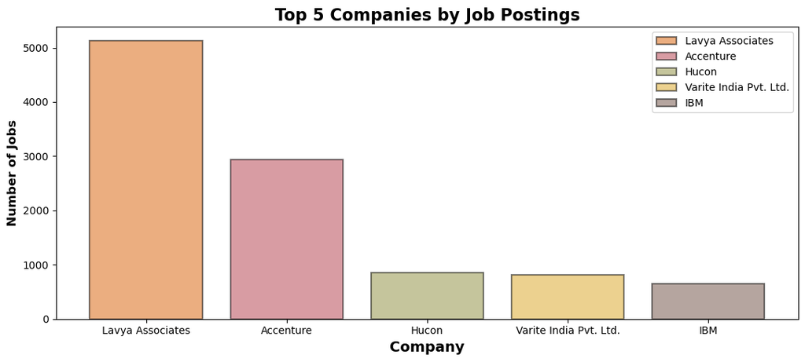

```python
top5=df["company"].value_counts().head().index
plt.figure(figsize=(11, 5))
plt.bar(top5, df["company"].value_counts().head().values,label=top5, color = ['#D95F02', '#B23A48', '#8C8C3A', '#DAA520', '#6D4C41'], edgecolor='black', linewidth=1.5,alpha=0.5)
plt.title('Top 5 Companies by Job Postings', fontweight='bold', fontsize=16)
plt.xlabel('Company', fontweight='bold', fontsize=14)
plt.ylabel('Number of Jobs', fontweight='bold', fontsize=12)
plt.legend()
plt.tight_layout()
plt.show()
```

## 4.3 Top 5 Companies based on Reviews

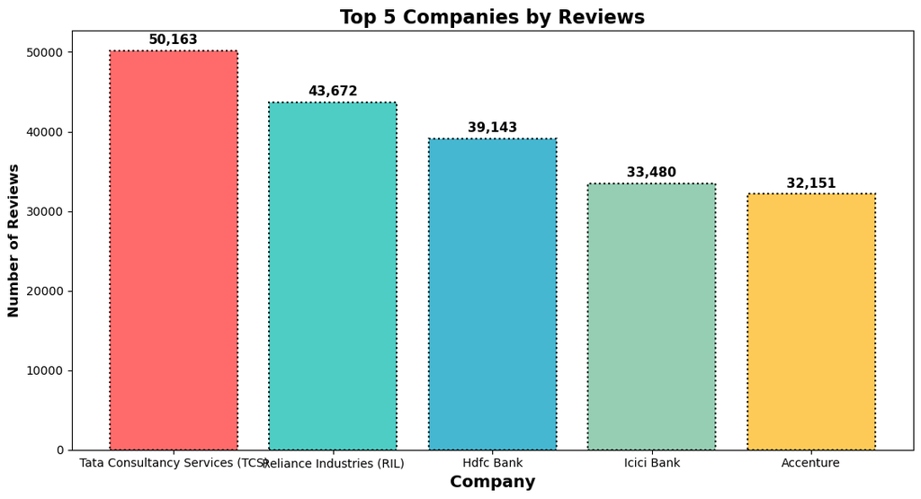

```python
top=df.groupby("company")["reviews"].max().sort_values(ascending=False).head()
companies = top.index
review_counts = top.values


plt.figure(figsize=(11, 6))
plt.bar(companies, review_counts, color=['#FF6B6B', '#4ECDC4', '#45B7D1', '#96CEB4', '#FECA57'], edgecolor='black', linewidth=1.5,linestyle=":")
plt.title('Top 5 Companies by Reviews', fontweight='bold', fontsize=16)
plt.xlabel('Company', fontweight='bold', fontsize=14)
plt.ylabel('Number of Reviews', fontweight='bold', fontsize=12)
plt.tight_layout()

for i, v in enumerate(review_counts):
    plt.text(i, v + max(review_counts)*0.01, f'{int(v):,}',
             ha='center', va='bottom', fontweight='bold', fontsize=11)
```

## 4.4 distribution of top 5 companies that have heighest job openings using pie chart

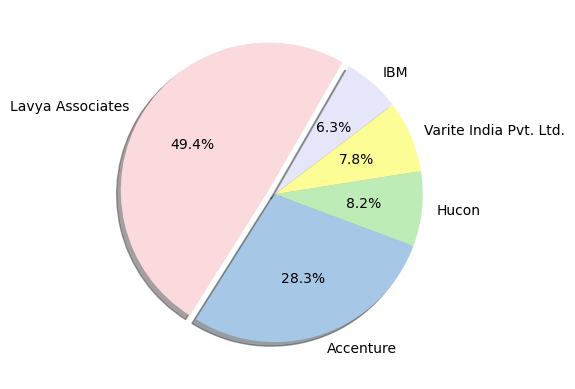

```python
plt.pie(list(df["company"].value_counts()[0:5]),labels=list(df["company"].value_counts()[0:5].keys()),startangle=60,autopct="%0.1f%%",colors = ['#FADADD', '#A7C7E7', '#BDECB6', '#FDFD96', '#E6E6FA'],shadow=True,explode=[0.05,0,0,0,0])
plt.show()
```

## 4.5 Companies that are actively hiring for Data Analyst roles using haorizontal bars?

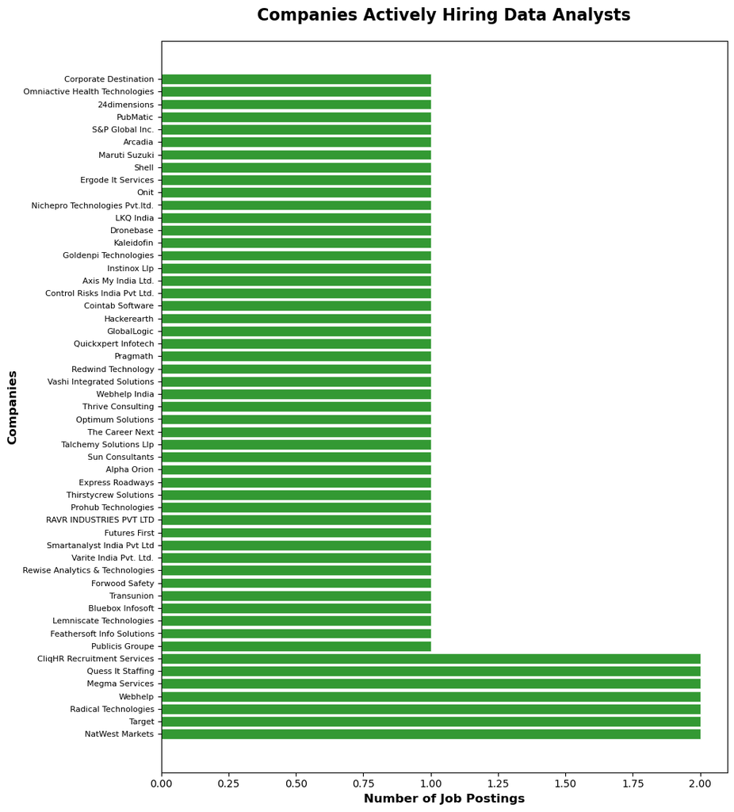

```python
company_counts = df[df["job_role"]=="Data Analyst"]["company"].value_counts()
colors = [
    "#4169E1", "#FFD700", "#36004C", "#DC143C", "#50C878",
    "#800020", "#C0C0C0", "#191970", "#CD7F32", "#E0115F",
    "#704214", "#8B4513", "#228B22", "#B87333", "#D4AF37",
    "#9932CC", "#4B0082", "#000080", "#808000", "#9400D3",
    "#2F4F4F", "#A52A2A", "#6A5ACD", "#483D8B", "#FF4500"
]
plt.figure(figsize=(10, 13))
plt.barh(company_counts.index, company_counts.values,color="green", edgecolor='white', linewidth=0.5, alpha=0.8)
plt.title('Companies Actively Hiring Data Analysts', fontweight='bold', fontsize=16, pad=20)
plt.xlabel('Number of Job Postings', fontweight='bold', fontsize=12)
plt.ylabel('Companies',fontweight="bold", fontsize=12)
plt.yticks(range(len(company_counts)), company_counts.index, fontsize=8)
plt.show()
```

## 4.6 What are the most common skills needed to get a job in Hdfc Bank using horizontal bars?

```python
skill=df.loc[df["company"]=="Hdfc Bank"]["resposibilities"].str.split(",").explode().value_counts().head(10)
```

```python
skill
```

```
resposibilities
cross selling              7
Relationship Management    5
Sales                      5
Customer Service           4
banking                    4
Retail Branch Banking      4
HNI Client Handling        4
Portfolio Management       4
portfolio management       4
Treasury                   3
Name: count, dtype: int64
```

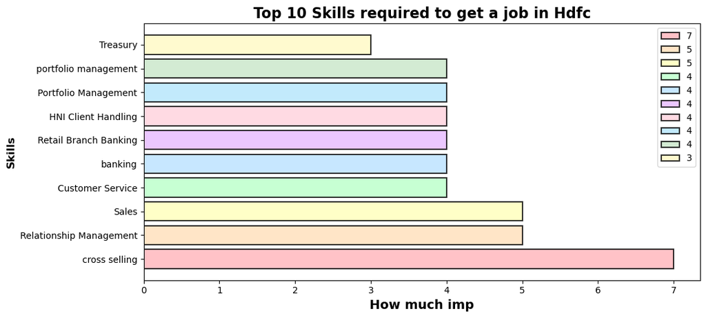

```python
plt.figure(figsize=(11, 5))
plt.barh(skill.index, skill.values,label=skill, color = ['#FFB3BA', '#FFDFBA', '#FFFFBA', '#BAFFC9', '#BAE1FF','#E6BAFF', '#FFD1DC', '#B3E5FC', '#C8E6C9', '#FFF9C4'], edgecolor='black', linewidth=1.5,alpha=0.8)
plt.title('Top 10 Skills required to get a job in Hdfc', fontweight='bold', fontsize=16)
plt.xlabel('How much imp', fontweight='bold', fontsize=14)
plt.ylabel('Skills', fontweight='bold', fontsize=12)
plt.legend()
plt.tight_layout()
plt.show()
```

## 4.7 What are the most common skills needed for almost all jobs?

```python
all=df["resposibilities"].str.split(",").explode().value_counts().head(10)
all
```

```
resposibilities
Sales                   4619
tied                    3310
agency                  3307
communication           2555
training                2218
Consulting              2104
Customer Service        2011
Java                    1976
Business Development    1966
team handling           1953
Name: count, dtype: int64
```

[figure not shown]

```python
plt.figure(figsize=(11, 5))
plt.barh(all.index, all.values,label=skill, color = ['#D63031', '#0984E3', '#00B894', '#E17055', '#6C5CE7',
         '#FDCB6E', '#FD79A8', '#00CEC9', '#FF7675', '#74B9FF',
         '#A29BFE'], edgecolor='black', linewidth=1.5,alpha=1)
plt.title('Most common skills to get all jobs', fontweight='bold', fontsize=16)
plt.xlabel('Count', fontweight='bold', fontsize=14)
plt.ylabel('Skills', fontweight='bold', fontsize=12)
plt.legend()
plt.tight_layout()
plt.show()
```

## 3.7 How does the number of jobs vary based on years of experience?

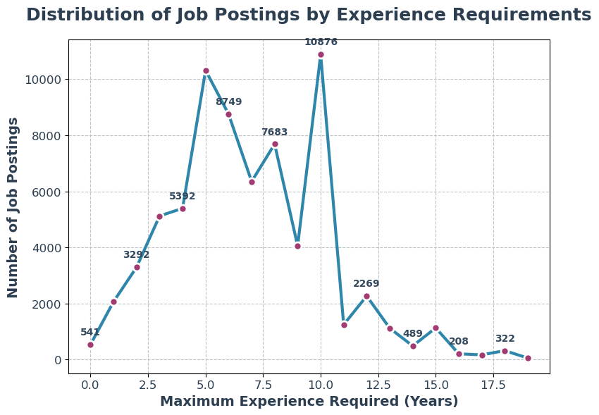

```python
plt.figure(figsize=(8, 6))
experience_counts = df.groupby("max_experience").size().head(20)
sns.lineplot(data=experience_counts,
                  linewidth=3,
                  marker='o',
                  markersize=8,
                  color='#2E86AB',
                  markerfacecolor='#A23B72',
                  markeredgecolor='white',
                  markeredgewidth=2)
plt.xlabel("Maximum Experience Required (Years)",
           fontweight="bold",
           fontsize=14,
           color='#2C3E50')

plt.ylabel("Number of Job Postings",
           fontweight="bold",
           fontsize=14,
           color='#2C3E50')

plt.title("Distribution of Job Postings by Experience Requirements",
          fontweight="bold",
          fontsize=18,
          color='#2C3E50',
          pad=20)

# Add value labels on data points
for i, (x, y) in enumerate(zip(experience_counts.index, experience_counts.values)):
    if i % 2 == 0:  # Show every other label to avoid crowding
        plt.annotate(f'{y}',
                    (x, y),
                    textcoords="offset points",
                    xytext=(0,10),
                    ha='center',
                    fontsize=10,
                    fontweight='bold',
                    color='#34495E')


plt.grid(True, linestyle='--', alpha=1, color='#BDC3C7')
plt.xticks(fontsize=12, color='#2C3E50')
plt.yticks(fontsize=12, color='#2C3E50')
plt.tight_layout()
plt.show()
```

## 3.8 What is the average salary for specific experience levels?

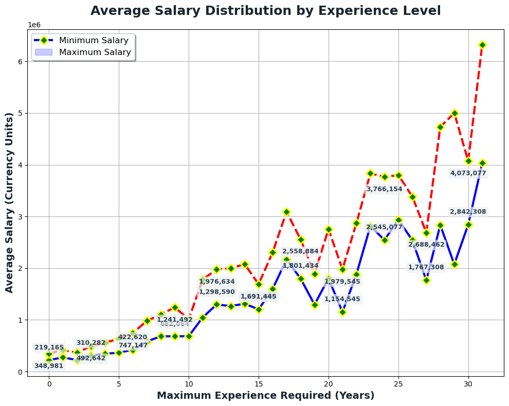

```python
plt.figure(figsize=(10, 8))
avg_salary = df.groupby(["max_experience"]).agg({"min_salary":"mean","max_salary":"mean"}).round(2)
sns.lineplot(data=avg_salary,
             linewidth=3,
             marker="D",
             markersize=8,
             palette=['blue', 'red'],
             markerfacecolor='green',
             markeredgecolor='yellow',
             markeredgewidth=2,
             linestyle=":")

plt.xlabel("Maximum Experience Required (Years)",
           fontweight="bold",
           fontsize=14,
           color='#1A252F')

plt.ylabel("Average Salary (Currency Units)",
           fontweight="bold",
           fontsize=14,
           color='#1A252F')

plt.title("Average Salary Distribution by Experience Level",
          fontweight="bold",
          fontsize=18,
          color='#1A252F',
          pad=20)

for col_idx, column in enumerate(avg_salary.columns):
    for i, (x, y) in enumerate(zip(avg_salary.index, avg_salary[column].values)):
        if i % 3 == 0:
            plt.annotate(f'{y:,.0f}',
                        (x, y),
                        textcoords="offset points",
                        xytext=(0, 15 if col_idx == 0 else -20),
                        ha='center',
                        fontsize=9,
                        fontweight='bold',
                        color='#2C3E50',
                        bbox=dict(boxstyle="round,pad=0.3",
                                facecolor='#ECF0F1',
                                alpha=0.7,
                                edgecolor='none'))

plt.grid(True)

plt.legend(['Minimum Salary', 'Maximum Salary'],
                   loc='upper left',
                   frameon=True,
                   fancybox=True,
                   shadow=True,
                   fontsize=12,
                   facecolor='#FDFEFE',
                   edgecolor='#BDC3C7')
plt.tight_layout()
plt.show()
```

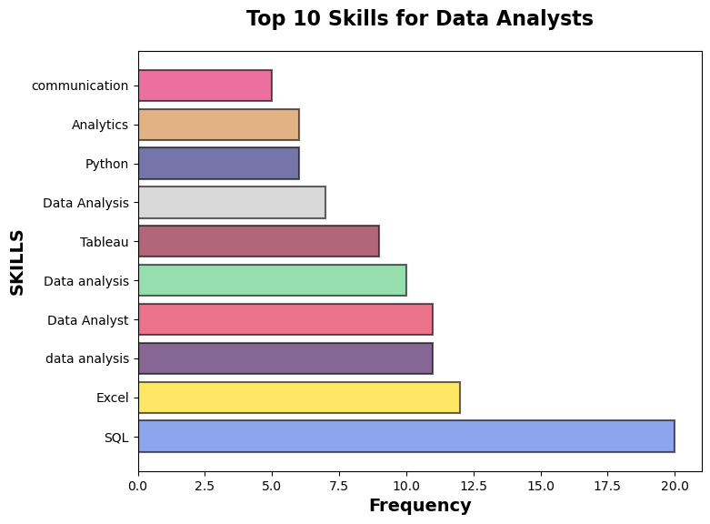

```python
s=df.loc[df["job_role"]=="Data Analyst"]["resposibilities"].str.split(",").explode().value_counts().head(10)
colors = ["#4169E1", "#FFD700", "#36004C", "#DC143C", "#50C878", "#800020", "#C0C0C0", "#191970", "#CD7F32", "#E0115F"]
plt.figure(figsize=(8,6))
plt.barh(s.index, s.values,
                color=colors,
                edgecolor='black',
                linewidth=1.5,
                alpha=0.6)
plt.xlabel('Frequency', fontsize=14, fontweight='bold')
plt.ylabel('SKILLS', fontsize=14, fontweight='bold')
plt.title('Top 10 Skills for Data Analysts',
          fontsize=16, fontweight='bold', pad=20)
plt.show()
```